# semi_20180420_1

Yutaka Kuroki

2018年4月18日

# 1 はじめに

## 1.1 目的

- TDAの分析の流れを知る, 共有する
- Bloombergコンペ, mazda プロジェクトへのアプローチの一つになれば幸い

## 1.2 TDA(Topological Data analysis)とは

位相幾何的な特徴の抽出を狙った分析である  
従来のstochasticな分析では得られなかった知見が得られれば幸い  
TDAの基本的なツールとして、persistent homologyやmapperがある  
今回はpersistent homologyのみ扱う

# 2 persistent homologyとその表現

point cloudの各点を中心とする超球を考える。  
半径を増やしていったとき、ホモロジーが誕生(Birth)しては消える(Death)ことになる。  
この永続性を見ることをpersistent homologyという

persistent homology は、半径$r$を用いて$Birth(r), Death(r)$によって与えられえることになる。  
その表現、要約方法が盛んに開発されてきた。

## 2.1 persistent diagram

最も基本的なのがpersistent diagram(PD)である。  
これは横軸に$Birth$, 縦軸に$Death$をとったホモロジーの散布図である。  
ホモロジーの次元により色を変えるのが一般的であり、可視化手法としては優れている。  
しかし、PDをもとに主観的な判断を下すことは望ましくない

## 2.2 maximum persistetnce

$$\text{max}(Death(r) - Birth(r))$$

## 2.3 persistence landscape

PDのさらに要約として、persistence landscapeがよく用いられる。  
ノイズを含んだ実データでは、生まれてすぐに死ぬホモロジーが多数存在することになる。  
つまり、より強い永続性を持ったものに着目することが重要であるとかんがえられる。

$p$番目のホモロジーで$Birth(r)=b, Death(r)=d$であったとする。そのとき、次の区分線形関数を考える
$$\Lambda_p(t) = \cases{
t-b, & b < t < (b+d)/2 \\
d-t, & (b+d)/2< t < d\\
0 & otherwise
}$$
ここで、persistence landscapeを
$$F(t) = \text{sup}(\Lambda_p(t))$$
で与える。

## 2.4 persustent barcode

ホモロジーが生まれてから死ぬまでを実線で表して並べたものをpersistent barcodeという。  
ただし、並べ方を決めなくてはならない

## 2.5 betti sequence

barcode

## 2.6 PD間の距離

Wasserstein distanceやbottleneck distanceというPD間の類似性を測る指標が提案されている  
よくわかっていないので要調査。組み合わせ爆発が起きるので計算が大変らしい

# 3 時系列へのアプローチ

point cloudさえ作ってしまえばpersistent homologyを計算することが出来る  
主に用いられるのは、時間遅れ座標を用いた埋め込み(embedding)である  
1次元である時系列データを任意の次元に埋め込むことが出来る

しかし、以下のような悩ましいポイントがある

- 時系列データの期間をどのようにするのか
- 何次元に埋め込むのか($m$)
- 時間遅れ座標の単位をどのようにすべきか($\tau$)

## 3.1 データ期間について

一つの時系列から複数のpoint cloudを作成するために、スライド窓を用いる場合がある  
位相幾何的な性質の移り変わりを見ることが出来る

## 3.2 何次元に埋め込むのか

ターケンスの埋め込み定理やFNN(False Nearest Neibor)がよく知られている。

## 3.3 時間遅れ座標の単位$\tau$

大きすぎるとサンプルが減るし、少なすぎても特徴が抽出できない場合がある  
系列の周期の整数倍は用いないほうが良い。  
自己相関関数を推定し参考にすることもある

# 4 事例紹介（人工データ）

## 4.1 pure data

次のような関数を考える

$$y = 4sin(x)sin(32x) + 4x$$

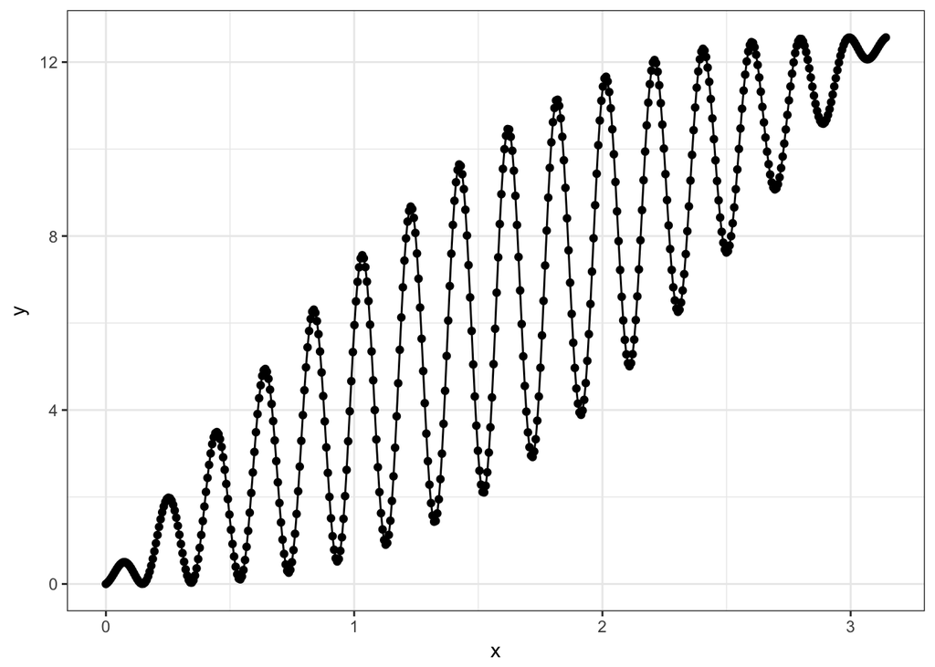

時間遅れ単位$\tau$を1, 20, 50, 100と変え3次元に埋め込んだ結果を次に示す

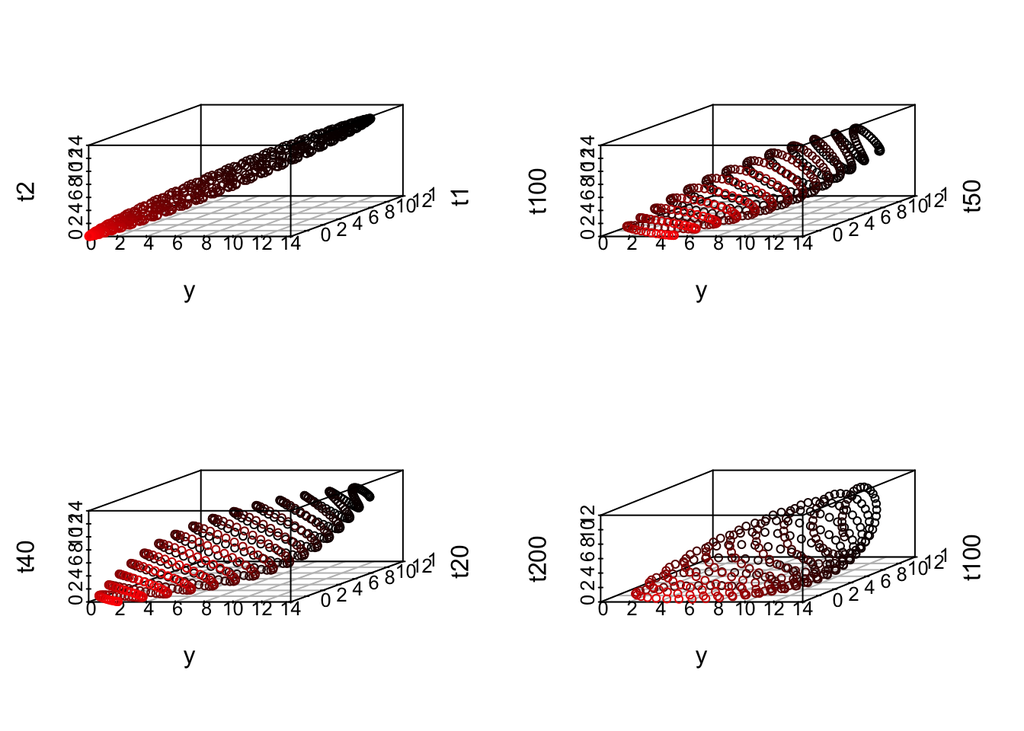

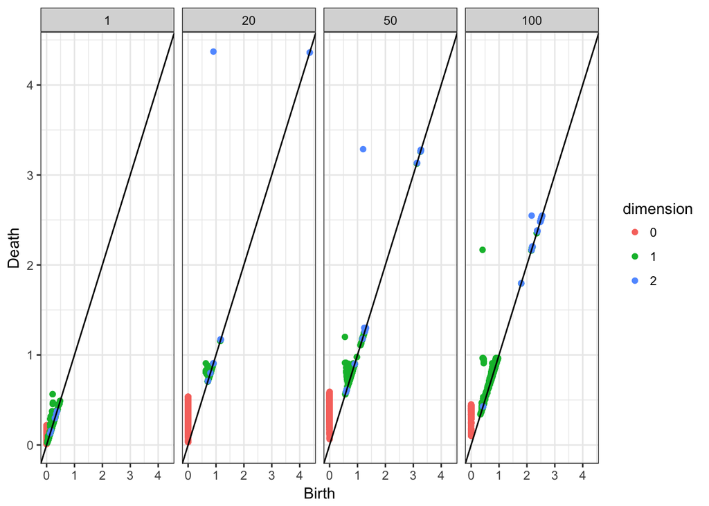

2次元のホモロジーなら$\tau = 20$、1次元のホモロジーなら$\tau = 100$ではっきりと出ていることが分かる

続いてlandscapeのを示す

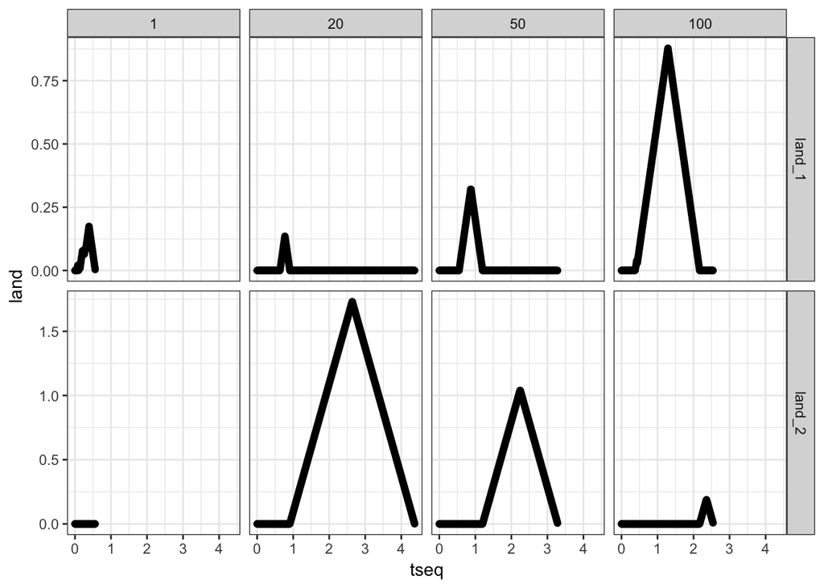

$\tau = 1$の場合にはうまく特徴が抽出できていないことが分かる。

続けてbarcode

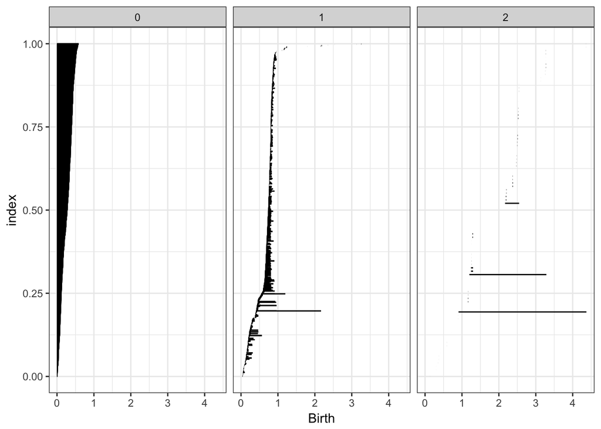

### 4.1.1 PCA

$\tau = 1$の場合でも、PCAを噛ませることで幾何的情報（特に2次元のホモロジー）は取り出せることが示される。  
上のPDと比較されたい

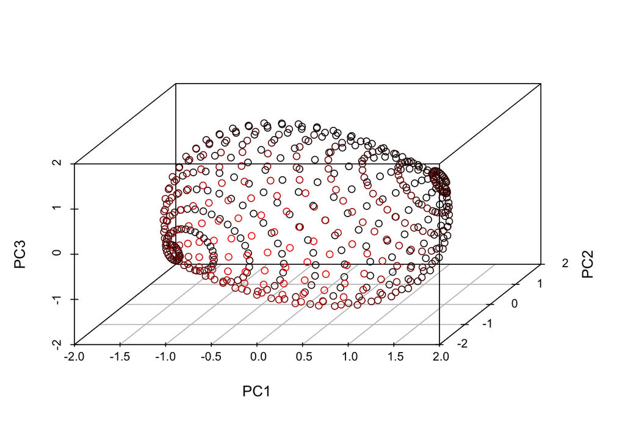

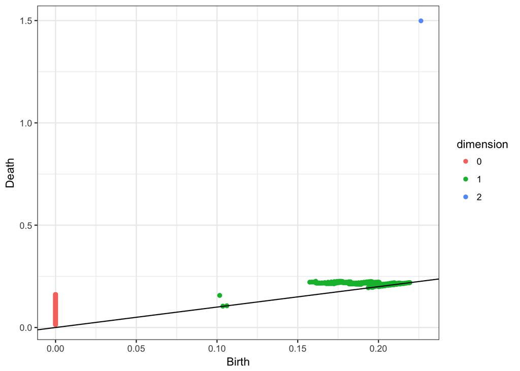

## 4.2 noisy data

先ほどのデータにノイズを付与する

$$y = 4sin(x)sin(32x) + 4x + \varepsilon\\
\varepsilon \sim N(\mu=0, \sigma = 0.5)$$

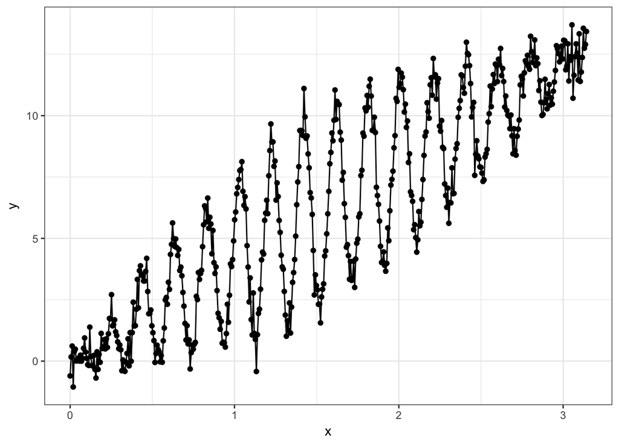

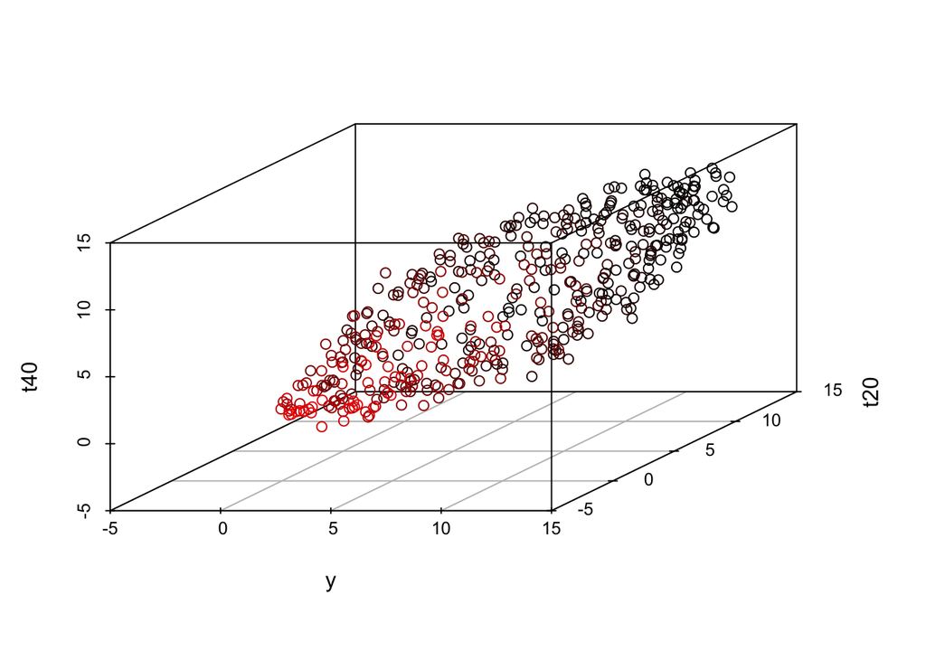

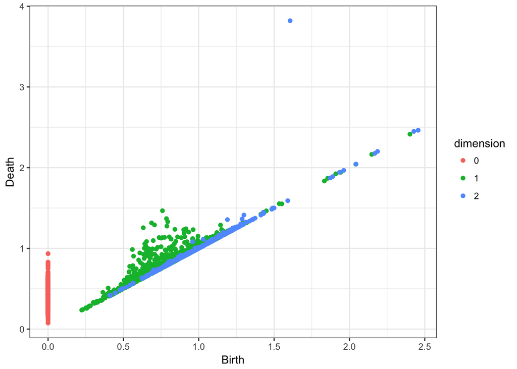

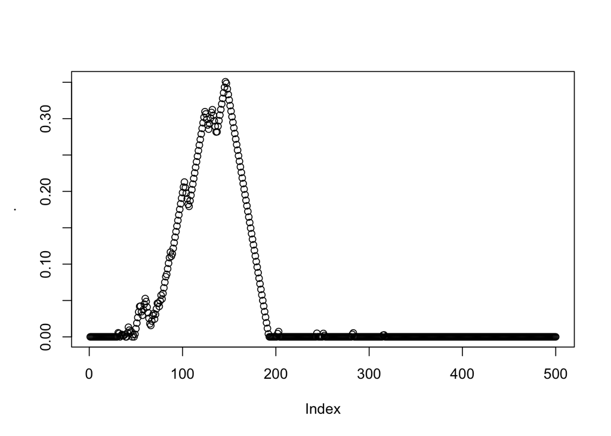

### 4.2.1 smoothing

移動平均を考えることでsmoothingをかける  
ここでは移動平均の窓の長さを10とした

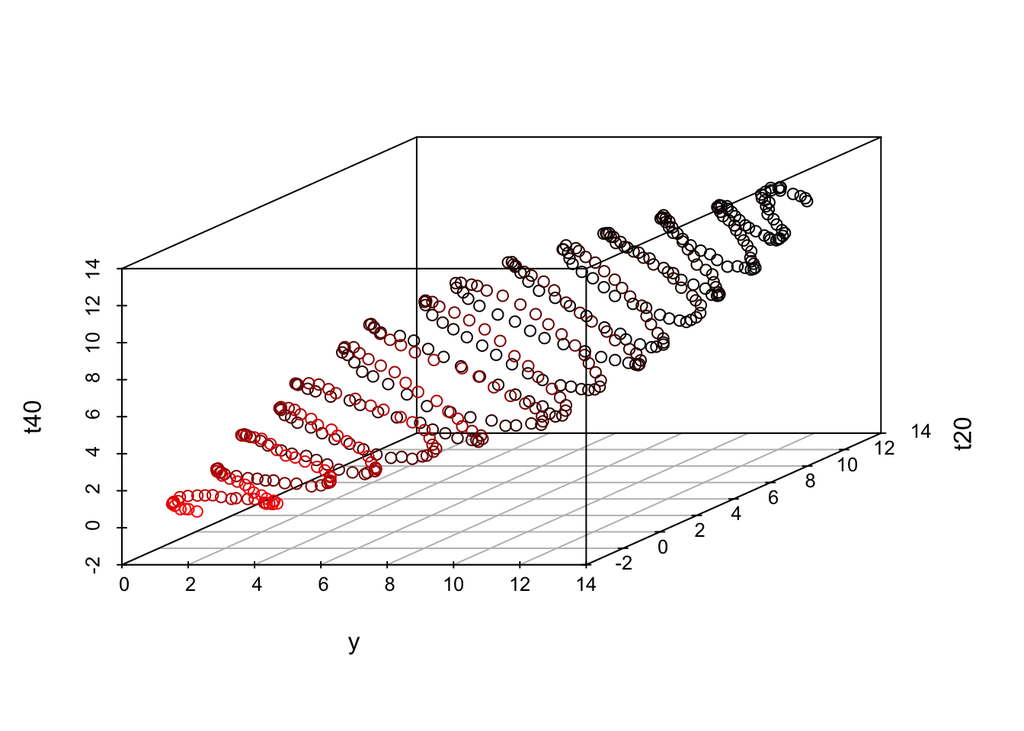

MAによりノイズを低減することができた。  
ノイズの入っていないときのPDと比較されたい  
ただしlandscapeを考える場合、弱い永続性を持つホモロジーは潰されてしまうので、ノイズの幾何的情報が見れなくなってしまうとも考えられる。

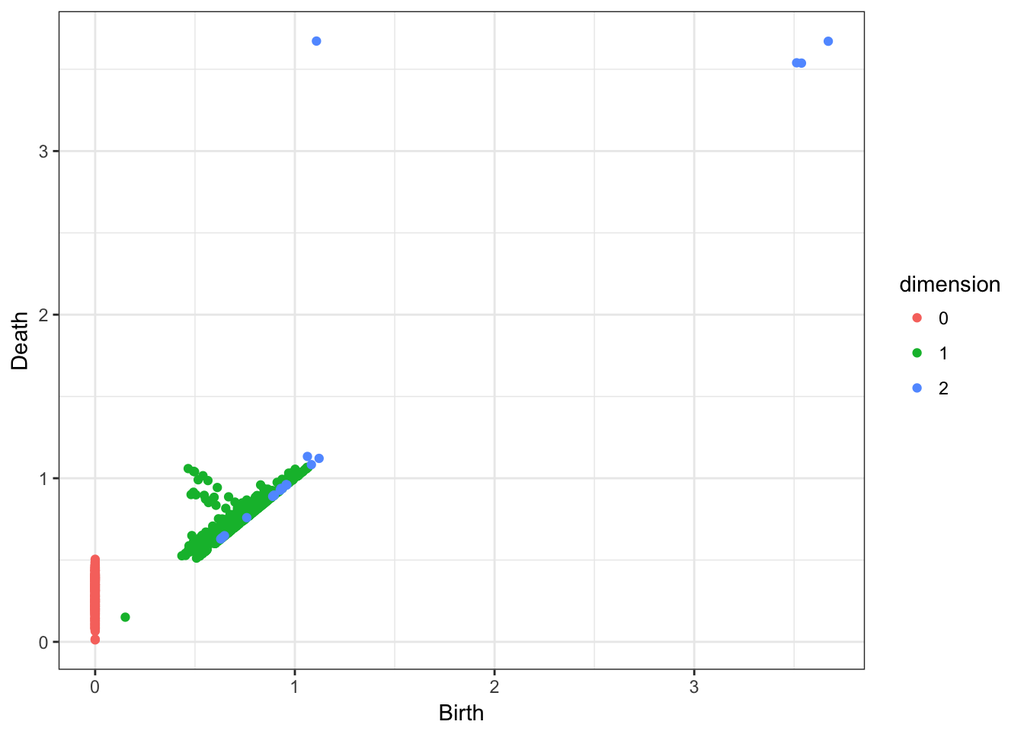

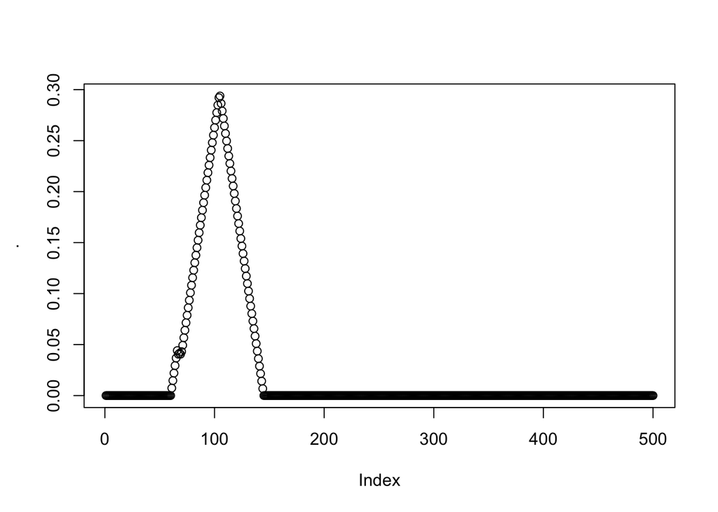

# 5 参考文献

- Truong, P. (2017). An exploration of topological properties of high-frequency one-dimensional financial time series data using TDA (Dissertation). Retrieved from http://urn.kb.se/resolve?urn=urn:nbn:se:kth:diva-220355
- Fasy, Brittany & Kim, Jisu & Lecci, Fabrizio & Maria, Clément. (2014). Introduction to the R package TDA.
- Yuhei Umeda, Time Series Classification via Topological Data Analysis, 人工知能学会論文誌, 公開日 2017/05/01, Online ISSN 1346-8030, Print ISSN 1346-0714, https://doi.org/10.1527/tjsai.D-G72, https://www.jstage.jst.go.jp/article/tjsai/32/3/32_D-G72/_article/-char/ja